# Building intuition into popgen fundamentals and inference

### Part 6: Simulating a defined set of individuals

You have now both a compiled *slendr* `model` and a well-defined sampling `schedule`.

**Use your combined sampling schedule stored in the `schedule` variable to run a new tree-sequence simulation from your model (again using the `msprime()` function), this time restricted to just those individuals scheduled for recording. You can do this by providing the combined sampling `schedule` as the `samples = schedule` argument of the function `msprime` you used above.** Just replace the line(s) with your first `msprime()` from the previous part of this exercise with the new one, which uses the `schedule` for your customized sampling.

**Also, while you’re doing this, use the `ts_mutate()` function to add overlay neutral mutations on the simulated tree sequence right after the `msprime()` call.** (Take a look at the handounts for a reminder of the `%>%` pipe patterns I showed you.)

**Click to see the solution**

```r
# The command below will likely take a few minutes to run, so feel free to go
# down from 100 Mb sequence_length to even 10Mb (it doesn't matter much).
# (The `random_seed =` argument is there for reproducibility purposes.)
ts <-
  msprime(model, sequence_length = 100e6, recombination_rate = 1e-8, samples = schedule, random_seed = 1269258439) %>%
  ts_mutate(mutation_rate = 1e-8, random_seed = 1269258439)
# Time difference of 2.141642 mins

# If you're bothered by ho long this takes, feel free to call these two lines
# to 100% reproduce my results without any expensive computation:
model <- read_model(here::here("data/introgression"))
ts <- ts_read(here::here(file = "data/introgression.trees"), model = model)

# We can save a tree sequence object using a slendr function `ts_write` (this
# can be useful if we want to save the results of a simulation for later use).
dir.create("data", showWarnings = FALSE)
ts_write(ts, "data/introgression.trees")
```

**Inspect the tree-sequence object saved in the `ts` variable by typing it into the R console again (this interactivity really helps with catching nasty bugs early during the programming of your script). You can also do a similar thing via the table produced by the `ts_samples()` function. You should see a much smaller number of individuals being recorded, indicating that the simulation was much more efficient and produced genomic data for only the individuals of interest.**

**Note:** When you think about it, it’s actually quite astonishing how fast *msprime* and *tskit* are when dealing with such a huge amount of sequence data from tens of thousands of individuals on a simple laptop!

**Click to see the solution**

```r
# Inspect the (tskit/Python-based) summary of the new tree sequence
ts
```

```
╔═══════════════════════════╗
║TreeSequence               ║
╠═══════════════╤═══════════╣
║Trees          │     295199║
╟───────────────┼───────────╢
║Sequence Length│  100000000║
╟───────────────┼───────────╢
║Time Units     │generations║
╟───────────────┼───────────╢
║Sample Nodes   │         76║
╟───────────────┼───────────╢
║Total Size     │   85.1 MiB║
╚═══════════════╧═══════════╝
╔═══════════╤═══════╤═════════╤════════════╗
║Table      │Rows   │Size     │Has Metadata║
╠═══════════╪═══════╪═════════╪════════════╣
║Edges      │1051064│ 32.1 MiB│          No║
╟───────────┼───────┼─────────┼────────────╢
║Individuals│     38│  1.1 KiB│          No║
╟───────────┼───────┼─────────┼────────────╢
║Migrations │      0│  8 Bytes│          No║
╟───────────┼───────┼─────────┼────────────╢
║Mutations  │ 663287│ 23.4 MiB│          No║
╟───────────┼───────┼─────────┼────────────╢
║Nodes      │ 218703│  5.8 MiB│          No║
╟───────────┼───────┼─────────┼────────────╢
║Populations│      4│341 Bytes│         Yes║
╟───────────┼───────┼─────────┼────────────╢
║Provenances│      2│  5.7 KiB│          No║
╟───────────┼───────┼─────────┼────────────╢
║Sites      │ 660993│ 15.8 MiB│          No║
╚═══════════╧═══════╧═════════╧════════════╝
```

```r
# Get the table of all recorded samples in the tree sequence
ts_samples(ts)
```

```
# A tibble: 38 × 3
   name   time pop
   <chr> <dbl> <chr>
 1 NEA_1 70000 NEA
 2 EUR_1 40000 EUR
 3 NEA_2 40000 NEA
 4 EUR_2 38000 EUR
 5 EUR_3 36000 EUR
 6 EUR_4 34000 EUR
 7 EUR_5 32000 EUR
 8 EUR_6 30000 EUR
 9 EUR_7 28000 EUR
10 EUR_8 26000 EUR
# ℹ 28 more rows
```

```r
# Compute the count of individuals in different time points
library(dplyr)

ts_samples(ts) %>% group_by(pop, time == 0) %>% tally %>% select(pop, n)
```

```
# A tibble: 5 × 2
# Groups:   pop [4]
  pop       n
  <chr> <int>
1 AFR       5
2 CHIMP     1
3 EUR      20
4 EUR      10
5 NEA       2
```

# Exercise 2: Computing popgen statistics on tree sequences from *slendr*

In this exercise, you will build on top of the results from Exercise 1. Specifically, we will learn how to compute popgen statistics on *slendr*-simulated tree sequences using [*slendr*’s interface](https://www.slendr.net/reference/index.html#tree-sequence-statistics) to the *tskit* Python module.

First, create a new R script `exercise2.R` and paste in the following code. This is one of the possible solutions to the Exercise 1, and it’s easier if we all use it to be on the same page from now on, starting from the same model and the same simulated tree sequence:

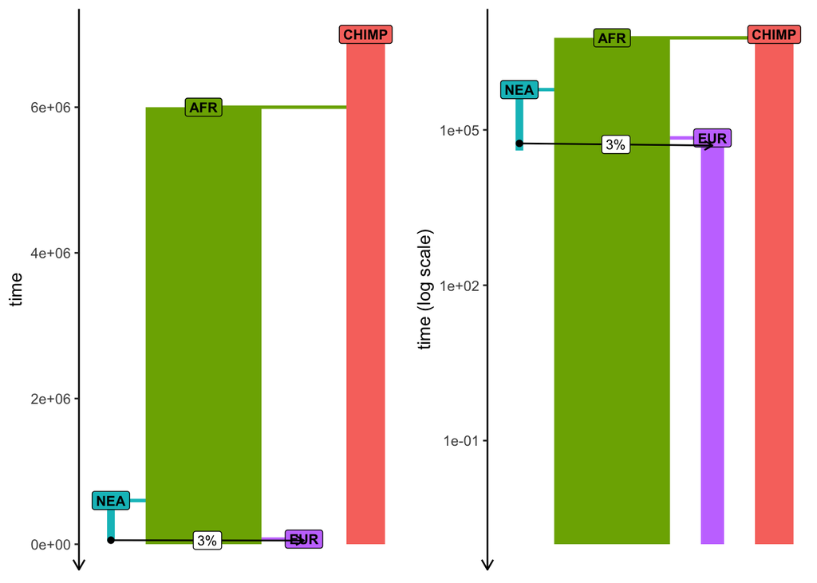

```r
library(slendr)
init_env()
## The interface to all required Python modules has been activated.

chimp <- population("CHIMP", time = 7e6, N = 5000)
afr <- population("AFR", parent = chimp, time = 6e6, N = 15000)
eur <- population("EUR", parent = afr, time = 70e3, N = 3000)
nea <- population("NEA", parent = afr, time = 600e3, N = 1000, remove = 40e3)

gf <- gene_flow(from = nea, to = eur, rate = 0.03, start = 55000, end = 50000)

model <- compile_model(
  populations = list(chimp, nea, afr, eur),
  gene_flow = gf,
  generation_time = 30
)

# We will read a cached version of a tree sequence to make sure we're all on
# the same page. That said, if you managed to do Exercise 1 on your own, feel
# free to stick with your own simulated tree sequence!
ts <- ts_read(here::here("data/introgression.trees"), model = model)

cowplot::plot_grid(
  plot_model(model, proportions = TRUE),
  plot_model(model, proportions = TRUE, log = TRUE),
  nrow = 1
)
```

As a sanity check, let’s use a couple of tidyverse table-munging tricks to make sure the tree sequence does contain a set of sample which matches our intended sampling schedule (particularly the time series of European individuals and the two Neanderthals):

```r
library(dplyr)

# total number of recorded individuals in the tree sequence
ts_samples(ts) %>% nrow
```

```
[1] 38
```

```r
# times of sampling of each recorded European individual
ts_samples(ts) %>% filter(pop == "EUR") %>% pull(time)
```

```
 [1] 40000 38000 36000 34000 32000 30000 28000 26000 24000 22000 20000 18000
[13] 16000 14000 12000 10000  8000  6000  4000  2000     0     0     0     0
[25]     0     0     0     0     0     0
```

```r
# times of sampling of each recorded Neanderthal
ts_samples(ts) %>% filter(pop == "NEA") %>% pull(time)
```

```
[1] 70000 40000
```

```r
# count of individuals in each population
ts_samples(ts) %>%
  group_by(pop, present_day = time == 0) %>%
  tally %>%
  select(pop, present_day, n) %>%
  arrange(present_day)
```

```
# A tibble: 5 × 3
# Groups:   pop [4]
  pop   present_day     n
  <chr> <lgl>       <int>
1 EUR   FALSE          20
2 NEA   FALSE           2
3 AFR   TRUE            5
4 CHIMP TRUE            1
5 EUR   TRUE           10
```

**Note:** These bits of tidyverse code are extremely helpful when you’re working with large tree sequences with many individuals as sanity checks that your sampling worked as intended. I’m listing them here in case you’ve never worked with the tidyverse family of R packages before (such as the *dplyr* package where `filter()`, `group_by()`, `tally()`, and `pull()` come from).

Everything looks good! Having made sure that the `ts` object contains the individuals we want, let’s move to the exercise.

## Part 1: Computing nucleotide diversity

The toy model of ancient human history plotted above makes a fairly clear prediction of what would be the nucleotide diversity expected in the simulated populations. **Compute the nucleotide diversity in all populations using the *slendr* function [`ts_diversity()`](https://www.slendr.net/reference/ts_diversity.html#ref-examples) in your tree sequence `ts`. Do you get numbers that (relatively between all populations) match what would expect from the model given the $N_e$ that you programmed for each?**

**Hint:** Nearly every *slendr* statistic function interfacing with *tskit* accepts a `ts` tree-sequence object as its first argument, with further arguments being either a vector of individual names representing a group of samples to compute a statistic on, or a (named) list of such vectors (each element of that list for a group of samples) – these lists are intended to be equivalent to the `sample_sets =` argument of many *tskit* Python methods (which you’ve learned about in your activity on *tskit*), except that they allow symbolic names of individuals, rather then integer indices of nodes in a tree sequence.

Although you can get all the above information by processing the table produced by the `ts_samples()` function, *slendr* provides a useful helper function `ts_names()` which only returns the names of individuals as a vector (or a named list of such vectors, one vector per population as shown below).

When you call it directly, you get a plain vector of individual names:

```r
ts_names(ts)
```

```
 [1] "NEA_1"   "EUR_1"   "NEA_2"   "EUR_2"   "EUR_3"   "EUR_4"   "EUR_5"
 [8] "EUR_6"   "EUR_7"   "EUR_8"   "EUR_9"   "EUR_10"  "EUR_11"  "EUR_12"
[15] "EUR_13"  "EUR_14"  "EUR_15"  "EUR_16"  "EUR_17"  "EUR_18"  "EUR_19"
[22] "EUR_20"  "AFR_1"   "AFR_2"   "AFR_3"   "AFR_4"   "AFR_5"   "CHIMP_1"
[29] "EUR_21"  "EUR_22"  "EUR_23"  "EUR_24"  "EUR_25"  "EUR_26"  "EUR_27"
[36] "EUR_28"  "EUR_29"  "EUR_30"
```

This is not super helpful, unless we want to compute some statistic for *everyone* in the tree sequence, regardless of their population assignment. Perhaps a bit more useful is to call the function like this, because it will produce a result which can be immediately used as the `sample_sets =` argument mentioned in the **Hint** above:

```r
ts_names(ts, split = "pop")
```

```
$AFR
[1] "AFR_1" "AFR_2" "AFR_3" "AFR_4" "AFR_5"

$CHIMP
[1] "CHIMP_1"

$EUR
 [1] "EUR_1"  "EUR_2"  "EUR_3"  "EUR_4"  "EUR_5"  "EUR_6"  "EUR_7"  "EUR_8"
 [9] "EUR_9"  "EUR_10" "EUR_11" "EUR_12" "EUR_13" "EUR_14" "EUR_15" "EUR_16"
[17] "EUR_17" "EUR_18" "EUR_19" "EUR_20" "EUR_21" "EUR_22" "EUR_23" "EUR_24"
[25] "EUR_25" "EUR_26" "EUR_27" "EUR_28" "EUR_29" "EUR_30"

$NEA
[1] "NEA_1" "NEA_2"
```

As you can see, this gave us a normal R list, with each element containing a vector of individual names in a population. Note that we can use standard R list indexing to get subsets of individuals:

```r
names <- ts_names(ts, split = "pop")

names["NEA"]
```

```
$NEA
[1] "NEA_1" "NEA_2"
```

```r
names[c("EUR", "NEA")]
```

```
$EUR
 [1] "EUR_1"  "EUR_2"  "EUR_3"  "EUR_4"  "EUR_5"  "EUR_6"  "EUR_7"  "EUR_8"
 [9] "EUR_9"  "EUR_10" "EUR_11" "EUR_12" "EUR_13" "EUR_14" "EUR_15" "EUR_16"
[17] "EUR_17" "EUR_18" "EUR_19" "EUR_20" "EUR_21" "EUR_22" "EUR_23" "EUR_24"
[25] "EUR_25" "EUR_26" "EUR_27" "EUR_28" "EUR_29" "EUR_30"

$NEA
[1] "NEA_1" "NEA_2"
```

etc.

Many of the following exercises will use these kinds of tricks to instruct various *slendr* / *tskit* functions to compute statistics on subsets of all individuals sub-sampled in this way.

**After you computed the nucleotide diversity per-population, compute it for each individual separately using the same function `ts_diversity()`** (which, in this setting, gives you effectively the heterozygosity for each individual).

**Hint:** You can do this by giving a vector of names as `sample_sets =` (so not an R list of vectors). Feel free to take a look at the solution if you find this distinction confusing.

**Click to see the solution**

**Population-based nucleotide diversity:**

```r
# Let's first get a named list of individuals in each group we want to be
# working with (slendr tree-sequence statistic functions generally operate
# with this kind of structure)
sample_sets <- ts_names(ts, split = "pop")
sample_sets
```

```
$AFR
[1] "AFR_1" "AFR_2" "AFR_3" "AFR_4" "AFR_5"

$CHIMP
[1] "CHIMP_1"

$EUR
 [1] "EUR_1"  "EUR_2"  "EUR_3"  "EUR_4"  "EUR_5"  "EUR_6"  "EUR_7"  "EUR_8"
 [9] "EUR_9"  "EUR_10" "EUR_11" "EUR_12" "EUR_13" "EUR_14" "EUR_15" "EUR_16"
[17] "EUR_17" "EUR_18" "EUR_19" "EUR_20" "EUR_21" "EUR_22" "EUR_23" "EUR_24"
[25] "EUR_25" "EUR_26" "EUR_27" "EUR_28" "EUR_29" "EUR_30"

$NEA
[1] "NEA_1" "NEA_2"
```

```r
# We can use such `sample_sets` object to compute nucleotide diversity (pi)\
# in each population, in a bit of a similar manner to how we would do it
# with the standard tskit in Python
pi_pop <- ts_diversity(ts, sample_sets = sample_sets)
arrange(pi_pop, diversity)
```

```
# A tibble: 4 × 2
  set   diversity
  <chr>     <dbl>
1 NEA   0.0000483
2 CHIMP 0.000196
3 EUR   0.000510
4 AFR   0.000600
```

You can see that this simple computation fits the extreme differences in long-term $N_e$ encoded by your *slendr* demografr model.

**Per-individual heterozygosity:**

We can do this by passing the vector of individual names directory as the `sample_sets =` argument, rather than in a list of groups as we did above.

```r
# For convenience, we first get a table of all individuals (which of course
# contains also their names) and in the next step, we'll just add their
# heterozygosities as a new column.
pi_df <- ts_samples(ts)
pi_df$name
```

```
 [1] "NEA_1"   "EUR_1"   "NEA_2"   "EUR_2"   "EUR_3"   "EUR_4"   "EUR_5"
 [8] "EUR_6"   "EUR_7"   "EUR_8"   "EUR_9"   "EUR_10"  "EUR_11"  "EUR_12"
[15] "EUR_13"  "EUR_14"  "EUR_15"  "EUR_16"  "EUR_17"  "EUR_18"  "EUR_19"
[22] "EUR_20"  "AFR_1"   "AFR_2"   "AFR_3"   "AFR_4"   "AFR_5"   "CHIMP_1"
[29] "EUR_21"  "EUR_22"  "EUR_23"  "EUR_24"  "EUR_25"  "EUR_26"  "EUR_27"
[36] "EUR_28"  "EUR_29"  "EUR_30"
```

```r
pi_df$diversity <- ts_diversity(ts, sample_sets = pi_df$name)$diversity
pi_df
```

```
# A tibble: 38 × 4
   name   time pop   diversity
   <chr> <dbl> <chr>     <dbl>
 1 NEA_1 70000 NEA   0.0000431
 2 EUR_1 40000 EUR   0.000516
 3 NEA_2 40000 NEA   0.0000410
 4 EUR_2 38000 EUR   0.000520
 5 EUR_3 36000 EUR   0.000539
 6 EUR_4 34000 EUR   0.000534
 7 EUR_5 32000 EUR   0.000533
 8 EUR_6 30000 EUR   0.000553
 9 EUR_7 28000 EUR   0.000499
10 EUR_8 26000 EUR   0.000506
# ℹ 28 more rows
```

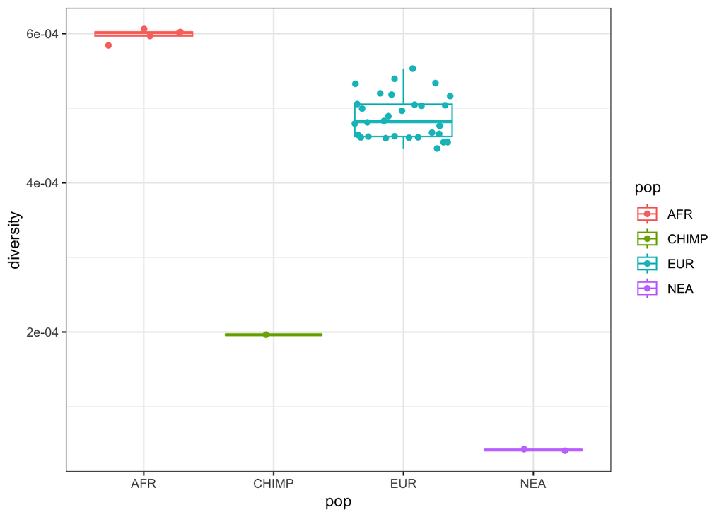

```r
# Let's plot the results using the ggplot2 package
# (because a picture is worth a thousand numbers!)
library(ggplot2)

ggplot(pi_df, aes(pop, diversity, color = pop, group = pop)) +
  geom_boxplot(outlier.shape = NA) +
  geom_jitter() +
  theme_bw()
```

## Part 2: Computing pairwise divergence

**Use the function [`ts_divergence()`](https://www.slendr.net/reference/ts_divergence.html#ref-examples) to compute genetic divergence between all pairs of populations. Again, do you get results compatible with our demographic model in terms of expectation given the split times between populations as you programmed them for your model?**

**Hint:** Again, you can use the same concept of `sample_sets =` we discussed in the previous part. In this case, the function computes *pairwise* divergence between each element of the list given as `sample_sets =` (i.e., for each vector of individual names).

**Click to see the solution**

```r
sample_sets <- ts_names(ts, split = "pop")

div_df <- ts_divergence(ts, sample_sets)
arrange(div_df, divergence)
```

```
# A tibble: 6 × 3
  x     y     divergence
  <chr> <chr>      <dbl>
1 AFR   EUR     0.000649
2 EUR   NEA     0.000955
3 AFR   NEA     0.000983
4 CHIMP NEA     0.00416
5 CHIMP EUR     0.00417
6 AFR   CHIMP   0.00418
```

## Part 3: Detecting Neanderthal admixture in Europeans

Let’s now pretend its about 2008, we’ve sequenced the first Neanderthal genome, and we are working on a project that will [change human evolution research forever](https://www.science.org/doi/10.1126/science.1188021). We also have the genomes of a couple of people from Africa and Europe, which we want to use to answer the most burning question of all evolutionary anthropology: *“Do some people living today carry Neanderthal ancestry?”*

Earlier you’ve learned about $f$-statistics of various kinds. You have also heard that an $f_4$ statistic (or its equivalent $D$ statistic) can be used as a test of “treeness”. Simply speaking, for some “quartet” of individuals or population samples, they can be used as a hypothesis test of whether the history of those samples is compatible with there not having been an introgression.

**Compute the $f_4$ test of Neanderthal introgression in EUR individuals using the *slendr* function `ts_f4()`.** When you’re running it, you will have to provide individuals to compute the statistic on using a slightly different format. Take a look at the help page available as `?ts_f4` for more information. **When you’re computing the $f_4$, make sure to set `mode = "branch"` argument of the `ts_f4()` function (we will get to why a bit later).**

**Note:** By default, each *slendr* / *tskit* statistic function operates on mutations, and this will switch them to use branch length (as you might know, $f$-statistics are mathematically defined using branch lengths in trees and `mode = "branch"` does exactly that).

**Hint:** If you haven’t learned this in your $f$-statistics lecture, you want to compute (and compare) the values of these two statistics using the *slendr* function `ts_f4()`:

1. $f_4$(<some African>, <another African>; <Neanderthal>, <Chimp>)
2. $f_4$(<some African>, <a test European>; <Neanderthal>, <Chimp>),

here `<individual>` can be the name of any individual recorded in your tree sequence, such as names you saw as `name` column in the table returned by `ts_samples(ts)` (i.e. `"NEA_1"` could be used as a “representative” `<Neanderthal>` in those equations, similarly for `"CHIMP_1"` as the fourth sample in the $f_4$ quarted representing the outgroup).

To simplify things a lot, we can understand the above equations as comparing the counts of so-called BABA and ABBA allele patterns between the quarted of samples specified in the statistics:

$$f_4(AFR, X; NEA, CHIMP) = \frac{\#BABA - \#ABBA}{\#SNPs}$$

The first $f_4$ statistic above is not expected to give values “too different” from 0 (even in case of Neanderthal introgression into Europeans) because we don’t expect two African individuals to differ “significantly” in terms of how much alleles they share with a Neanderthal (because their ancestors never met Neanderthals!). The other should – if there was a Neanderthal introgression into Europeans some time in their history – be “significantly negative”.

**Is the second of those two statistics “much more negative” than the first, as expected assuming introgression from Neanderthals into Europeans?**

**In the text right above, why am I putting “significantly” and “much more negative” in quotes? What are we missing here for this being a true hypothesis test as you might be accustomed to from computing** $f$-statistics using a tool such as ADMIXTOOLS? (We will get to this again in the following part of this exercise.)

**Click to see the solution**

```r
# Compute the difference in the amount of allele sharing between two African
# individuals and a Neanderthal
f4_null <- ts_f4(ts, W = "AFR_1", X = "AFR_2", Y = "NEA_1", Z = "CHIMP_1", mode = "branch")
f4_null
```

```
# A tibble: 1 × 5
  W     X     Y     Z          f4
  <chr> <chr> <chr> <chr>   <dbl>
1 AFR_1 AFR_2 NEA_1 CHIMP_1  43.4
```

```r
# Compute the difference in the amount of allele sharing between an African
# individual vs European individual and a Neanderthal
f4_alt <- ts_f4(ts, W = "AFR_1", X = "EUR_1", Y = "NEA_1", Z = "CHIMP_1", mode = "branch")
f4_alt
```

```
# A tibble: 1 × 5
  W     X     Y     Z          f4
  <chr> <chr> <chr> <chr>   <dbl>
1 AFR_1 EUR_1 NEA_1 CHIMP_1 -853.
```

```r
# We can see that the second test resulted in an f4 value about ~20 times more
# negative than the first test, indicating that a European in our test carries
# "significantly more" Neanderthal alleles compared to the baseline expectation
# of no introgression established by the comparison to an African ...
f4_alt$f4 / f4_null$f4
```

```
[1] -19.65719
```

```r
# ... although this is not a real test of significance (we have no Z-score or
# standard error which would give us something like a p-value for the hypothesis
# test, as we get by jackknife procedure in ADMIXTOOLS)
```

The fact that we don’t get something equivalent to a p-value in these kinds of simulations is generally not a problem, because we’re often interested in establishing a trend of a statistic under various conditions, and understanding when and how its *expected value* behaves in a certain way. If statistical noise is a problem, we work around this by computing a statistic on multiple simulation replicates or even increasing the sample sizes.

**Note:** To see this in practice, you can check out a [paper](https://www.pnas.org/doi/10.1073/pnas.1814338116#fig02) in which I used this approach quite successfully on a related problem.

On top of that, p-value of something like an $f$-statistic (whether it’s significantly different from zero) is also strongly affected by quality of the data, sequencing errors, coverage, etc. (which can certainly be examined using simulations!). However, these are aspects of modeling which are quite orthogonal to the problem of investigating the expectations and trends of statistics given some underlying evolutionary model, which is what we’re after in these exercises.

That said, even in perfect simulated data, what exactly does “significantly different from zero compared to some baseline expectation” mean can be blurred by noise with simple single-individual comparisons that we did above. Let’s increase the sample size a bit to see if a statistical pattern expected in $f_4$ statistic from our Neanderthal introgression model becomes more apparent.

**Compute the first $f_4$ statistic of the baseline expectation between a pair of Africans and the second $f_4$ statistic comparing an African and a European, but this time on *all recorded Africans* and *all recorded Europeans*, respectively. Plot the *distributions* of those two sets of statistics. This should remove lots of the uncertainty and make a statistical trend stand out much more clearly.**

**Hint:** Whenever you need to compute something for many things in sequence, looping is very useful. One way to do compute, say, an $f_4$ statistic over many individuals is by using this kind of pattern using R’s looping function `lapply()`:

```r
# Loop over vector of individual names (variable x) and apply a given ts_f4()
# expression on each individual (note the ts_f4(..., X = x, ...) in the code)
list_f4 <- lapply(
  c("ind_1", "ind_2", ...),
  function(x) ts_f4(ts, W = "AFR_1", X = x, Y = "NEA_1", Z = "CHIMP_1", mode = "branch")
)

# The above gives us a list of data frames, so we need to bind them all into a
# single table for easier interpretation and visualization
df_f4 <- do.call(rbind, list_f4)
```

**Click to see the solution**

```r
# This gives us list of vectors of the names of all individuals in each
# population...
sample_sets <- ts_names(ts, split = "pop")
# ... which we can then access like this
sample_sets$AFR # all Africans
```

```
[1] "AFR_1" "AFR_2" "AFR_3" "AFR_4" "AFR_5"
```

```r
sample_sets$EUR # all Europeans
```

```
 [1] "EUR_1"  "EUR_2"  "EUR_3"  "EUR_4"  "EUR_5"  "EUR_6"  "EUR_7"  "EUR_8"
 [9] "EUR_9"  "EUR_10" "EUR_11" "EUR_12" "EUR_13" "EUR_14" "EUR_15" "EUR_16"
[17] "EUR_17" "EUR_18" "EUR_19" "EUR_20" "EUR_21" "EUR_22" "EUR_23" "EUR_24"
[25] "EUR_25" "EUR_26" "EUR_27" "EUR_28" "EUR_29" "EUR_30"
```

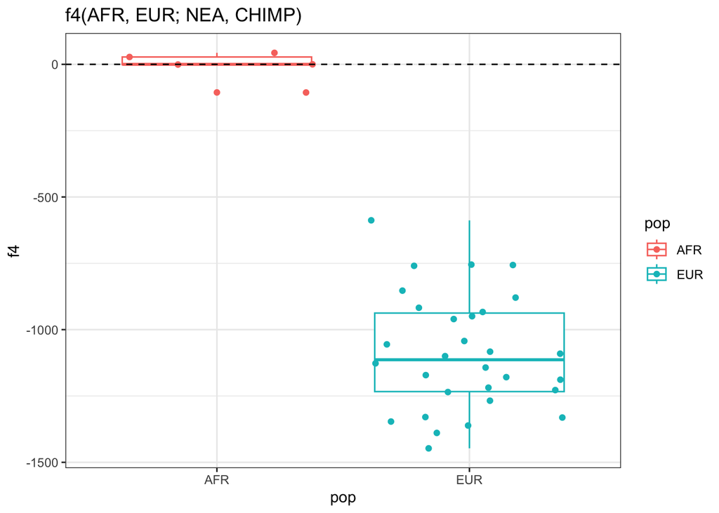

```r
# Let's compute the f4 statistic for all Africans...
f4_afr_list <- lapply(
  sample_sets$AFR,
  function(x) ts_f4(ts, W = "AFR_1", X = x, Y = "NEA_1", Z = "CHIMP_1", mode = "branch")
)
# ... and Europeans
f4_eur_list <- lapply(
  sample_sets$EUR,
  function(x) ts_f4(ts, W = "AFR_1", X = x, Y = "NEA_1", Z = "CHIMP_1", mode = "branch")
)

# Bind each list of data frames into a single data frame
f4_afr <- do.call(rbind, f4_afr_list)
f4_eur <- do.call(rbind, f4_eur_list)

# Let's add population columns to each of the two results for easier plotting
f4_afr$pop <- "AFR"
f4_eur$pop <- "EUR"

# Bind both tables together
f4_results <- rbind(f4_afr, f4_eur)

# Visualize the results
f4_results %>%
  ggplot(aes(pop, f4, color = pop)) +
  geom_boxplot() +
  geom_jitter() +
  geom_hline(yintercept = 0, linetype = 2) +
  ggtitle("f4(AFR, EUR; NEA, CHIMP)") +
  theme_bw()
```

**Bonus exercises**

### Bonus 1: `mode = "branch"` vs `mode = "site"`

**Repeat the previous part of the exercise by setting `mode = "site"` in the `ts_f4()` function calls** (this is actually the default behavior of all *slendr* tree-sequence based *tskit* functions). This will switch the *tskit* computation to using mutation counts along each branch of the tree sequence, rather than using branch length themselves. **Why might the branch-based computation be a bit better if what we’re after is investigating the expected values of statistics under some model?**

**Click to see the solution**

See [this tutorial](https://tskit.dev/tutorials/no_mutations.html#genealogy-based-measures-are-less-noisy) (and particularly the directly linked section) for explanation.

### Bonus 2: Outgroup $f_3$ statistic

**Use the function `ts_f3()` to compute the outgroup** $f_3$ statistic between pairs of African-European, African-Neanderthal, and European-Neanderthal and a Chimpanzee outgroup.

**Hint:** The $f_3$ statistic is traditionally expressed as $f_3(A, B; C)$, where C represents the outgroup. Unfortunately, in *tskit* the outgroup is named A, with B and C being the pair of samples from which we trace the length of branches towards the outgroup, so the statistic is interpreted as $f_3(B, C; A)$.

**How do the outgroup f3 results compare to your expectation based on simple population relationships (and to the divergence computation above)?**

**Do you see any impact of introgression on the $f_3$ value when a Neanderthal is included in the computation?**

**Click to see the solution**

```r
# f3(A, B; C) = E[ (A - C) * (B - C) ]
# This means that in tskit, C is the outgroup (different from ADMIXTOOLS!)

# We can compute f3 for individuals...
ts_f3(ts, B = "AFR_1", C = "EUR_1", A = "CHIMP_1")
```

```
# A tibble: 1 × 4
  A       B     C          f3
  <chr>   <chr> <chr>   <dbl>
1 CHIMP_1 AFR_1 EUR_1 0.00375
```

```r
# ... but also whole populations (or population samples)
ts_f3(ts, B = sample_sets["AFR"], C = sample_sets["EUR"], A = "CHIMP_1")
```

```
# A tibble: 1 × 4
  A       B     C          f3
  <chr>   <chr> <chr>   <dbl>
1 CHIMP_1 AFR   EUR   0.00375
```

```r
ts_f3(ts, B = sample_sets["AFR"], C = sample_sets["NEA"], A = "CHIMP_1")
```

```
# A tibble: 1 × 4
  A       B     C          f3
  <chr>   <chr> <chr>   <dbl>
1 CHIMP_1 AFR   NEA   0.00358
```

```r
ts_f3(ts, B = sample_sets["EUR"], C = sample_sets["NEA"], A = "CHIMP_1")
```

```
# A tibble: 1 × 4
  A       B     C          f3
  <chr>   <chr> <chr>   <dbl>
1 CHIMP_1 EUR   NEA   0.00359
```

### Bonus 3: Outgroup $f_3$ statistic as a linear combination of $f_2$ statistics

You might have learned that any complex $f$-statistic can be expressed as a linear combination of multiple $f_2$ statistics (which represent simple branch length separating two lineages). **Verify that this is the case by looking up equation *(20b)* in [this amazing paper](https://academic.oup.com/genetics/article/202/4/1485/5930214) and compute an** $f_3$ statistic for any arbitrary trio of individuals of your choosing using this linear combination of $f_2$ statistics.

**Click to see the solution**

```r
# standard f3
ts_f3(ts, B = "AFR_1", C = "AFR_2", A = "CHIMP_1")
```

```
# A tibble: 1 × 4
  A       B     C          f3
  <chr>   <chr> <chr>   <dbl>
1 CHIMP_1 AFR_1 AFR_2 0.00378
```

```r
# a "homemade" f3 statistic as a linear combination of f2 statistics
# f3(A, B; C) = f2(A, C) + f2(B, C) - f2(A, B) / 2
homemade_f3 <- (
  ts_f2(ts, A = "AFR_1", B = "CHIMP_1")$f2 +
  ts_f2(ts, A = "AFR_2", B = "CHIMP_1")$f2 -
  ts_f2(ts, A = "AFR_1", B = "AFR_2")$f2
) / 2
homemade_f3
```

```
[1] 0.003778796
```